# plyr_learn

### ddply 示例

#### 1 summarise + ddply

**对原始数据进行归纳，函数产生新的数据框显示，区别mutate函数（函数产生的变量和原始数据一起返回）**

```r
library(plyr)
head(baseball)
```

```
##            id year stint team lg  g  ab  r  h X2b X3b hr rbi sb cs bb so
## 4   ansonca01 1871     1  RC1    25 120 29 39  11   3  0  16  6  2  2  1
## 44  forceda01 1871     1  WS3    32 162 45 45   9   4  0  29  8  0  4  0
## 68  mathebo01 1871     1  FW1    19  89 15 24   3   1  0  10  2  1  2  0
## 99  startjo01 1871     1  NY2    33 161 35 58   5   1  1  34  4  2  3  0
## 102 suttoez01 1871     1  CL1    29 128 35 45   3   7  3  23  3  1  1  0
## 106 whitede01 1871     1  CL1    29 146 40 47   6   5  1  21  2  2  4  1
##     ibb hbp sh sf gidp
## 4    NA  NA NA NA   NA
## 44   NA  NA NA NA   NA
## 68   NA  NA NA NA   NA
## 99   NA  NA NA NA   NA
## 102  NA  NA NA NA   NA
## 106  NA  NA NA NA   NA
```

```r
summarise(baseball,
          duration = max(year) - min(year),
          nteams = length(unique(team)))
```

```
##   duration nteams
## 1      136    132
```

- **通常summarise结合plyr使用**

```r
newData <- ddply(baseball, "id")    # 按id分组,因为没有func函数，这里是按id顺序排序
head(newData)
```

```
##          id year stint team lg   g  ab   r   h X2b X3b hr rbi sb cs bb so
## 1 aaronha01 1954     1  ML1 NL 122 468  58 131  27   6 13  69  2  2 28 39
## 2 aaronha01 1955     1  ML1 NL 153 602 105 189  37   9 27 106  3  1 49 61
## 3 aaronha01 1956     1  ML1 NL 153 609 106 200  34  14 26  92  2  4 37 54
## 4 aaronha01 1957     1  ML1 NL 151 615 118 198  27   6 44 132  1  1 57 58
## 5 aaronha01 1958     1  ML1 NL 153 601 109 196  34   4 30  95  4  1 59 49
## 6 aaronha01 1959     1  ML1 NL 154 629 116 223  46   7 39 123  8  0 51 54
##   ibb hbp sh sf gidp
## 1  NA   3  6  4   13
## 2   5   3  7  4   20
## 3   6   2  5  7   21
## 4  15   0  0  3   13
## 5  16   1  0  3   21
## 6  17   4  0  9   19
```

```r
summarise(newData,                  # 对分组后的每组数据进行汇总
          duration = max(year) - min(year),
          nteams = length(unique(team)))
```

```
##   duration nteams
## 1      136    132
```

```r
df <- ddply(baseball, "id", summarise,    #按id分组，分组后每组数据在year变量和team变量上进行汇总
 duration = max(year) - min(year),
 nteams = length(unique(team)))

head(df)
```

```
##          id duration nteams
## 1 aaronha01       22      3
## 2 abernte02       17      7
## 3 adairje01       12      4
## 4 adamsba01       20      2
## 5 adamsbo03       13      4
## 6 adcocjo01       16      5
```

- **summarise后的函数相当于作用于分组后的数据**
- **一旦ddply结合summarise或mutate使用，后面的函数针对的是分组后的某列**

##### 2 多变量

```r
install.packages("plyr"")
```

```r
library(plyr)
dfx <- data.frame(         #生成数据
  group = c(rep('A', 8), rep('B', 15), rep('C', 6)),
  sex   = sample(c('M', 'F'), size = 29, replace = T),
  age   = runif(n = 29, min = 18, max = 54)
)
dfx
```

```
##    group sex      age
## 1      A   M 37.16779
## 2      A   M 40.39338
## 3      A   M 33.70493
## 4      A   M 47.40103
## 5      A   F 40.03140
## 6      A   M 18.23964
## 7      A   M 22.86810
## 8      A   F 18.69325
## 9      B   M 50.86651
## 10     B   F 21.72371
## 11     B   F 29.90713
## 12     B   F 21.55749
## 13     B   F 50.21241
## 14     B   M 35.47179
## 15     B   M 40.05724
## 16     B   M 24.55700
## 17     B   M 29.58574
## 18     B   F 40.41253
## 19     B   M 32.67444
## 20     B   F 34.07743
## 21     B   M 37.15465
## 22     B   F 48.58075
## 23     B   F 28.15361
## 24     C   M 40.32183
## 25     C   M 50.88316
## 26     C   M 20.43168
## 27     C   F 53.75056
## 28     C   M 31.10617
## 29     C   M 19.26311
```

```r
dd <- ddply(dfx, .(group, sex), summarize,       #按group和sex分别分组进行统计
 mean = round(mean(age), 2),
 sd = round(sd(age), 2))
head(dd)
```

```
##   group sex  mean    sd
## 1     A   F 29.36 15.09
## 2     A   M 33.30 10.95
## 3     B   F 34.33 11.16
## 4     B   M 35.77  8.39
## 5     C   F 53.75    NA
## 6     C   M 32.40 13.43
```

#### .(group, sex) 的效果等价于 c(“group”, “sex”)

##### 3 使用公式，多函数

```r
x <- baseball[1:100,]
head( ddply(x, ~ year+team, nrow) ) # 使用公式表示分组变量
```

```
##   year team V1
## 1 1871  CL1  2
## 2 1871  FW1  1
## 3 1871  NY2  1
## 4 1871  RC1  1
## 5 1871  TRO  1
## 6 1871  WS3  1
```

```r
x[x[,"year"]==1871 & x[,"team"]=='CL1',]    # 验证，发现确实如此
```

```
##            id year stint team lg  g  ab  r  h X2b X3b hr rbi sb cs bb so
## 102 suttoez01 1871     1  CL1    29 128 35 45   3   7  3  23  3  1  1  0
## 106 whitede01 1871     1  CL1    29 146 40 47   6   5  1  21  2  2  4  1
##     ibb hbp sh sf gidp
## 102  NA  NA NA NA   NA
## 106  NA  NA NA NA   NA
```

```r
head( ddply(baseball, .(team), c("nrow", "ncol")) )  # 使用两个函数，分组后每组多少行，多少列
```

```
##   team nrow ncol
## 1  ALT    1   22
## 2  ANA   45   22
## 3  ARI  105   22
## 4  ATL  477   22
## 5  BAL  680   22
## 6  BFN   41   22
```

##### 4 summarise + ddply

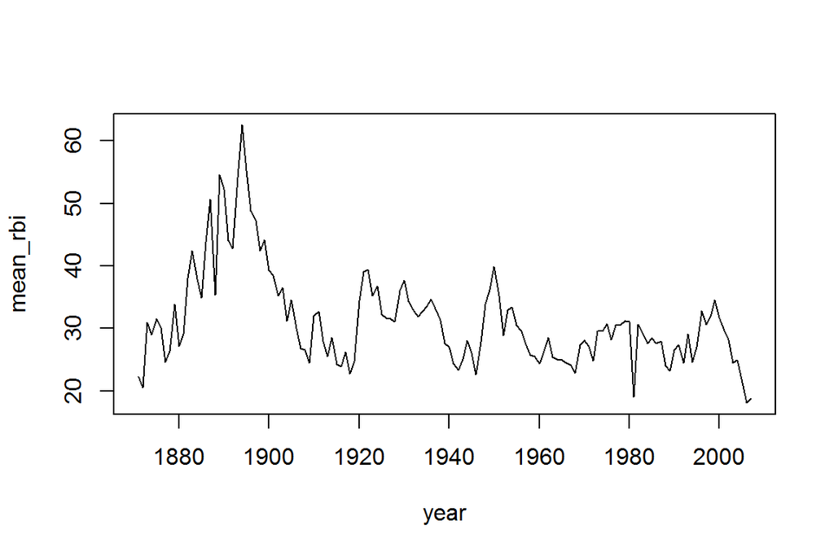

```r
rbi <- ddply(baseball, .(year), summarise,
  mean_rbi = mean(rbi, na.rm = TRUE))        #按year分组，对每组的rbi求均值
plot(mean_rbi ~ year, type = "l", data = rbi)
```

##### 5 mutate, 产生新的变量,返回原始数据+新变量

```r
df <- data.frame(id = rep(letters[1:3], each = 3),value = 1:9)
df
```

```
##   id value
## 1  a     1
## 2  a     2
## 3  a     3
## 4  b     4
## 5  b     5
## 6  b     6
## 7  c     7
## 8  c     8
## 9  c     9
```

```r
ddply(df, .(id), mutate, mean = mean(value))
```

```
##   id value mean
## 1  a     1    2
## 2  a     2    2
## 3  a     3    2
## 4  b     4    5
## 5  b     5    5
## 6  b     6    5
## 7  c     7    8
## 8  c     8    8
## 9  c     9    8
```

##### [深入理解mutate和summarise](http://stackoverflow.com/questions/26935150/use-of-ddply-mutate-with-a-custom-function)

**1、不用mutate、summarise** 1）作用于分组后的dataFrame上

```r
   ddply(iris, .(Species), nrow)
```

```
##      Species V1
## 1     setosa 50
## 2 versicolor 50
## 3  virginica 50
```

```
2）作用于分组后的某（些）列上
   2.1）使用inline函数
```

```r
   ddply(iris, .(Species), function(o) mean(o$Sepal.Length))    # 分类后每组length的均值
```

```
##      Species    V1
## 1     setosa 5.006
## 2 versicolor 5.936
## 3  virginica 6.588
```

```
   2.2）模拟summarise
```

```r
   mean.func.summarise <- function(df){
     data.frame( mean.length = mean( df$Sepal.Length ) )
}
   ddply(iris, .(Species), mean.func.summarise)
```

```
##      Species mean.length
## 1     setosa       5.006
## 2 versicolor       5.936
## 3  virginica       6.588
```

```
   2.3）模拟mutate
```

```r
   mean.func.mutate <- function(df){
     data.frame( df,mean.length = mean( df$Sepal.Length ) )
}
   head( ddply(iris, .(Species), mean.func.mutate)  )
```

```
##   Sepal.Length Sepal.Width Petal.Length Petal.Width Species mean.length
## 1          5.1         3.5          1.4         0.2  setosa       5.006
## 2          4.9         3.0          1.4         0.2  setosa       5.006
## 3          4.7         3.2          1.3         0.2  setosa       5.006
## 4          4.6         3.1          1.5         0.2  setosa       5.006
## 5          5.0         3.6          1.4         0.2  setosa       5.006
## 6          5.4         3.9          1.7         0.4  setosa       5.006
```

**2、使用mutate、summarise，函数就作用于分组后的某（些）列上**

```r
mean.func <- function(x) {
  mean(x + runif(length(x)))     #使用定制函数
}
ans <- ddply(iris, .(Species), mutate, jittered.mean.length = mean.func(Sepal.Length))
head(ans)
```

```
##   Sepal.Length Sepal.Width Petal.Length Petal.Width Species
## 1          5.1         3.5          1.4         0.2  setosa
## 2          4.9         3.0          1.4         0.2  setosa
## 3          4.7         3.2          1.3         0.2  setosa
## 4          4.6         3.1          1.5         0.2  setosa
## 5          5.0         3.6          1.4         0.2  setosa
## 6          5.4         3.9          1.7         0.4  setosa
##   jittered.mean.length
## 1             5.484006
## 2             5.484006
## 3             5.484006
## 4             5.484006
## 5             5.484006
## 6             5.484006
```

```r
ddply(iris, .(Species), summarize, jittered.mean.length = mean.func(Sepal.Length))
```

```
##      Species jittered.mean.length
## 1     setosa             5.497152
## 2 versicolor             6.497413
## 3  virginica             7.051317
```

##### 6 一个简单回归的例子

```r
model <- function(x) {
    lm(Petal.Length~Petal.Width,data=x)  # 首先定义回归函数
}
# 如果用普通的函数则需要如下的分割、计算、整合三个步骤共四条命令
pieces <- split(iris,list(iris$Species))  # 按品种分为3类
models <- lapply(pieces,model)            # 每个品种应用回归模型，得到3组参数
sapply(models,coef)                       # 组合结果
```

```
##                setosa versicolor virginica
## (Intercept) 1.3275634   1.781275 4.2406526
## Petal.Width 0.5464903   1.869325 0.6472593
```

** 用plyr包只用下面两个函数，每个函数都内置了分割、计算、整合的功能。**

```r
result1 <- dlply(iris,.(Species),model)
result1
```

```
## $setosa
##
## Call:
## lm(formula = Petal.Length ~ Petal.Width, data = x)
##
## Coefficients:
## (Intercept)  Petal.Width
##      1.3276       0.5465
##
##
## $versicolor
##
## Call:
## lm(formula = Petal.Length ~ Petal.Width, data = x)
##
## Coefficients:
## (Intercept)  Petal.Width
##       1.781        1.869
##
##
## $virginica
##
## Call:
## lm(formula = Petal.Length ~ Petal.Width, data = x)
##
## Coefficients:
## (Intercept)  Petal.Width
##      4.2407       0.6473
##
##
## attr(,"split_type")
## [1] "data.frame"
## attr(,"split_labels")
##      Species
## 1     setosa
## 2 versicolor
## 3  virginica
```

```r
result2 <- ldply(result1,function(x) coef(x))
result2
```

```
##      Species (Intercept) Petal.Width
## 1     setosa    1.327563   0.5464903
## 2 versicolor    1.781275   1.8693247
## 3  virginica    4.240653   0.6472593
```

##### 7 r*ply对应的是replicate函数。

```r
replicate(20,mean(runif(100)))       # 随机生成100个数计算均值，运行20次
```

```
##  [1] 0.5281113 0.5102323 0.5615452 0.4958018 0.4529953 0.5164909 0.4957801
##  [8] 0.5191854 0.5338269 0.5346784 0.5615024 0.4718888 0.4718372 0.4866438
## [15] 0.5251095 0.4489459 0.5071954 0.5290915 0.5435405 0.4995432
```

```r
rdply(20, mean(runif(100)))
```

```
##    .n        V1
## 1   1 0.4930810
## 2   2 0.5008062
## 3   3 0.4793547
## 4   4 0.4755623
## 5   5 0.5480534
## 6   6 0.5004578
## 7   7 0.4864425
## 8   8 0.4970336
## 9   9 0.5072815
## 10 10 0.5005535
## 11 11 0.4426346
## 12 12 0.4815902
## 13 13 0.5131971
## 14 14 0.5287681
## 15 15 0.5115800
## 16 16 0.4970038
## 17 17 0.4656501
## 18 18 0.5277051
## 19 19 0.4617951
## 20 20 0.4946621
```